# Homework 2 Notes

We will use the [BostonHousing: Boston Housing Data (BostonHousing2)](https://www.rdocumentation.org/packages/mlbench/versions/2.1-3/topics/BostonHousing) for this homework. The dataset is used for predicting the house price in Boston from house details.

- cmedv: target variable, corrected median value of owner-occupied homes in USD 1000’s
- age: proportion of owner-occupied units built prior to 1940
- dis: weighted distances to five Boston employment centres
- index of accessibility to radial highways

You can use the following commands to load Boston housing datasets in R, and check the information of dataset.

```r
library(mlbench)
# Boston Housing Data
data(BostonHousing2)
dim(BostonHousing2)
```

```
## [1] 506  19
```

```r
names(BostonHousing2)
```

```
##  [1] "town"    "tract"   "lon"     "lat"     "medv"    "cmedv"   "crim"
##  [8] "zn"      "indus"   "chas"    "nox"     "rm"      "age"     "dis"
## [15] "rad"     "tax"     "ptratio" "b"       "lstat"
```

## 1. Simple Linear Regression (50%)

- Scatter plot for cmedv (dependent variable Y) and age (independent variable X).
- Use the `lm` command to fit a linear regression model of cmedv with age as the predictor.
- Use the `summary` command to generate a summary of the regression.
- Interpret the output.
- Add the regression line to the scatter plot.

```r
## plot a x/y scatter plot with the data
plot(BostonHousing2$age, BostonHousing2$cmedv)

## create a "linear model" - that is, do the regression
model.housing=lm(cmedv~age, data=BostonHousing2)

## generate a summary of the regression
summary(model.housing)
```

```
##
## Call:
## lm(formula = cmedv ~ age, data = BostonHousing2)
##
## Residuals:
##     Min      1Q  Median      3Q     Max
## -15.091  -5.123  -1.952   2.404  31.346
##
## Coefficients:
##             Estimate Std. Error t value Pr(>|t|)
## (Intercept) 30.98438    0.99703  31.077   <2e-16 ***
## age         -0.12330    0.01345  -9.166   <2e-16 ***
## ---
## Signif. codes:  0 '***' 0.001 '**' 0.01 '*' 0.05 '.' 0.1 ' ' 1
##
## Residual standard error: 8.509 on 504 degrees of freedom
## Multiple R-squared:  0.1429, Adjusted R-squared:  0.1412
## F-statistic: 84.02 on 1 and 504 DF,  p-value: < 2.2e-16
```

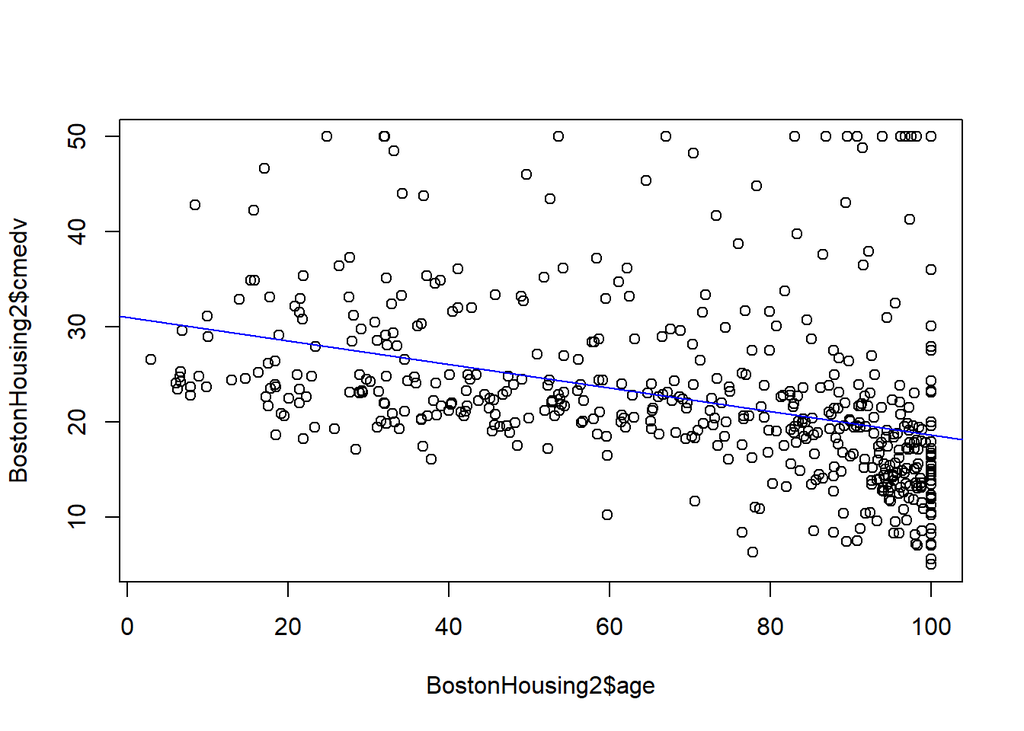

```r
## add the regression line to our x/y scatter plot
abline(model.housing, col="blue")
```

## 2. Multiple Linear Regression (50%)

- Use the `lm` command to build a multiple linear regression model for three independent variables, age, dis, and rad. That is, Y is cmedv, X are age, dis, and rad.
- Use the `summary` command to generate a summary of the regression.
- Interpret the output.
- Use `car::vif` command to check the independence assumption.

```r
## build a multiple linear regression model
model.housing.mul=lm(cmedv~age+dis+rad, data=BostonHousing2)
summary(model.housing.mul)
```

```
##
## Call:
## lm(formula = cmedv ~ age + dis + rad, data = BostonHousing2)
##
## Residuals:
##     Min      1Q  Median      3Q     Max
## -15.278  -5.064  -2.333   2.502  33.993
##
## Coefficients:
##             Estimate Std. Error t value Pr(>|t|)
## (Intercept) 36.98269    2.26556  16.324  < 2e-16 ***
## age         -0.12245    0.01967  -6.224 1.02e-09 ***
## dis         -0.79118    0.26928  -2.938  0.00345 **
## rad         -0.31987    0.04857  -6.585 1.15e-10 ***
## ---
## Signif. codes:  0 '***' 0.001 '**' 0.01 '*' 0.05 '.' 0.1 ' ' 1
##
## Residual standard error: 8.168 on 502 degrees of freedom
## Multiple R-squared:  0.2134, Adjusted R-squared:  0.2087
## F-statistic: 45.39 on 3 and 502 DF,  p-value: < 2.2e-16
```

```r
car::vif(model.housing.mul)
```

```
##      age      dis      rad
## 2.320971 2.433614 1.354007
```